# Lecture 12 — Spatial Transcriptomics: Gene Expression in Tissue Context

Bill Cresko

# Lecture 12: Spatial Transcriptomics

## Where this lecture fits

- Previous: Lec 09 — WGCNA
- **You are here:** Lec 12 — *measuring gene expression while keeping the tissue context*
- Next: Lec 11 — FAIR Principles & Data Sharing
- **Companion tutorial:** Tutorial 11 — Spatial Transcriptomics with Visium
- **Parallel reading:** [scNotebooks Module 10](https://integrativebioinformatics.github.io/scNotebooks/modules/en/module10/module10.html)

## Goals of this lecture

- Understand **what spatial transcriptomics measures** that scRNA-seq cannot
- Compare the major technologies — **Visium**, **Visium HD**, **Xenium**, **MERFISH**, **CosMx** — by resolution / throughput / coverage
- Read a Visium experiment as a **spot-level** dataset (≠ single-cell)
- Apply the standard analysis pipeline: QC → SCTransform → cluster → spatially variable features → integration
- Know when to use **deconvolution** (RCTD, CARD, cell2location) vs **spatial clustering** (BANKSY, STAGATE)
- Recognize the limits — bin size vs cell size, edge artifacts, depth heterogeneity

# Part 1 — What does “spatial” buy us?

## The dissociation lie

scRNA-seq starts with **dissociation**: tissue → cell suspension. That gives you each cell’s transcriptome but loses **everywhere it ever was** in the tissue. For developmental biology, immunology, and disease microenvironments, position is the answer to half your questions.

- Where in the tumor are the exhausted T cells? Adjacent to which tumor sub-clones?
- In the developing kidney, which transcriptional state precedes which?
- Are immune cells in the ductal periphery or the lobular core? Granular / scattered or concentrated in foci?
- Which genes are expressed only at tissue boundaries, where dissociation would shred the spatial signal?

## Spatial transcriptomics at a glance

[figure not shown]

Spatial preview — what gets measured, where, and how

- Counts plus **coordinates** — every observation has a `(x, y)` location in the tissue
- Different platforms make different trade-offs between **resolution**, **gene panel size**, and **field-of-view**
- The downstream toolchain reuses scRNA-seq machinery but adds spatial-aware steps (Moran’s I, deconvolution, region detection)

## What spatial measures

[figure not shown]

# Part 2 — The technologies

## The landscape

| Technology | Resolution | Throughput | Genome coverage | Best for |
| --- | --- | --- | --- | --- |
| **10x Visium (v1, v2)** | 55 µm spots | ~5,000 spots / section | Whole transcriptome | First spatial study; tissue overview |
| **10x Visium HD** | 2 µm bins (sub-cellular) | ~6 M bins / section | Whole transcriptome | High-res Visium replacement (2023+) |
| **10x Xenium** | Single-cell, sub-cellular | 100k–500k cells | 200–5000 gene panel | Single-cell-resolution spatial; targeted panels |
| **MERFISH** (Vizgen) | Sub-cellular | 100k–1M cells | Up to ~1000 genes | High plex, single-cell resolution |
| **NanoString CosMx** | Sub-cellular | similar to MERFISH | Up to ~1000 genes (extending to whole-tx) | Clinical samples, FFPE |
| **Slide-seq / Slide-tags** | 10 µm | ~50k beads | Whole-tx (Slide-seq); Xenium-like (Slide-tags) | Higher resolution than Visium, less spatial-uniform |
| **GeoMx DSP** (Nanostring) | Region-of-interest | 100s of ROIs | Whole-tx or panel | Pathology-driven ROI analysis |

**Note**

**Two axes to watch.** *Resolution* (spot vs cell vs sub-cellular) and *coverage* (whole-transcriptome vs targeted panel). Visium is high-coverage / low-resolution; Xenium is targeted / high-resolution. The right choice depends on whether your hypothesis is “where in the tissue is gene X expressed?” (panel suffices) or “what are the cell-type-specific expression programs?” (whole-transcriptome better).

## Visium 101 — the workhorse

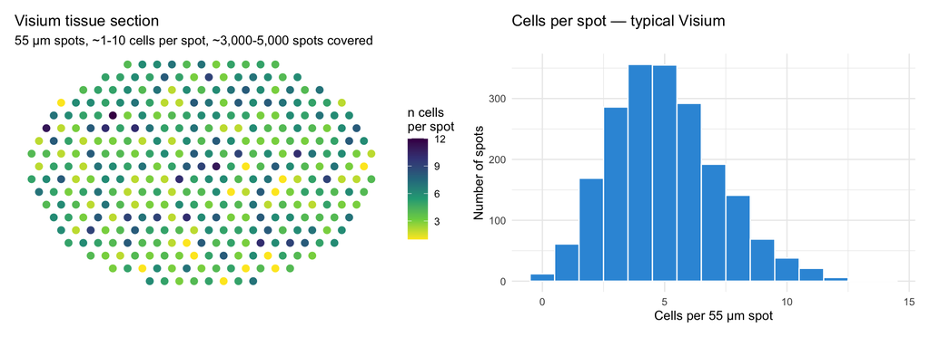

The key constraint: **a Visium spot is not a single cell.** Your “marker gene” expression at one spot is a **mixture** of whatever cells are within it. This shapes everything downstream — clustering recovers tissue regions (not cell types), DE recovers region-vs-region differences, and “deconvolution” is its own analytical step.

## Visium HD — sub-cellular bins

In 2023 10x released **Visium HD** with 2 µm × 2 µm capture squares (much smaller than a cell). Output bins at 8 µm (~1 cell) or 16 µm (multi-cell) provide the choice between resolution and depth. Same chemistry as classic Visium but ~1000× more bins per section.

For atlas-scale work in 2026, Visium HD has largely replaced classic Visium. The analysis pipeline is the same; the file sizes are bigger.

# Part 3 — The Visium analysis pipeline

## Spot-level QC — three metrics, plus a fourth

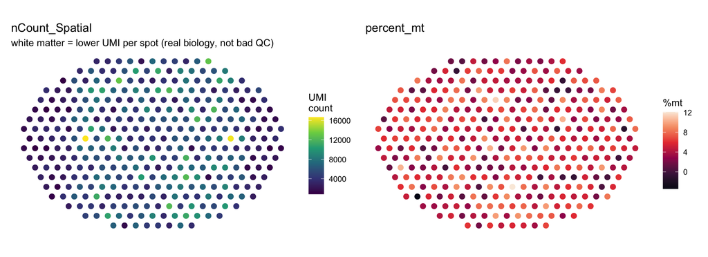

Per-spot QC metrics generalize from scRNA-seq (`nCount_Spatial`, `nFeature_Spatial`, `percent.mt`) but you should **always plot them on the tissue** — *spatial QC* is the fourth metric:

- A localized region of low UMI counts? White matter, edge artifacts, bubbles. Don’t filter blindly.
- A localized region of high `percent.mt`? Could be necrotic tissue (real biology) or storage damage (technical).
- Correlated drops in both? The spot is on tissue but in poor condition.

## Why SCTransform on Visium

Visium spots have a wider dynamic range than single cells (each spot is 1–10 cells). `LogNormalize` works but `SCTransform` is preferred — its regularized negative binomial models the depth-vs-variance relationship more cleanly at the spot level.

```r
library(Seurat)
brain <- LoadData("stxBrain", type = "anterior1")
brain <- SCTransform(brain, assay = "Spatial", verbose = FALSE)
```

## Clustering — but the clusters are *regions*, not cell types

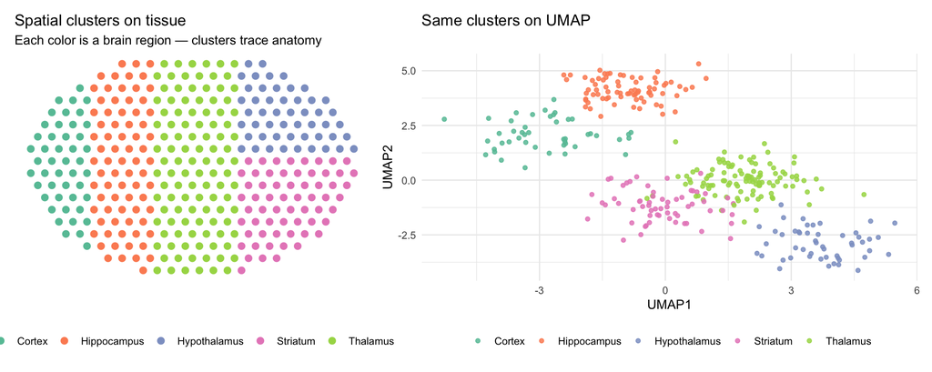

**Tip**

A spatial cluster that occupies **one contiguous anatomical region** is biologically meaningful (cortex, hippocampus, etc.). A cluster scattered as random spots across the section is typically a technical signature (depth, ambient RNA) — not real biology.

## Spatially variable features — Moran’s I

Some genes vary spot-to-spot **with spatial structure** (clear pattern on the tissue); some vary spot-to-spot but spatially randomly. The first kind is what you want.

**Moran’s I** is the standard test:

$$I = \frac{N}{W} \cdot \frac{\sum_i \sum_j w_{ij} (x_i - \bar x)(x_j - \bar x)}{\sum_i (x_i - \bar x)^2}$$

where $w_{ij}$ is the spatial weight (large for spatially close spots, zero for far). High Moran’s I means high spatial autocorrelation — adjacent spots have similar expression.

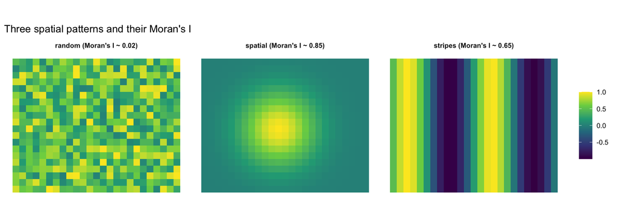

# Part 4 — Cell-type deconvolution

## The mixture problem

Each Visium spot ≈ 1–10 cells. If a spot’s cluster is “putative neuron-rich region”, which kinds of neurons? In what proportions?

**Deconvolution** decomposes each spot’s mixture using a single-cell **reference** of the same tissue:

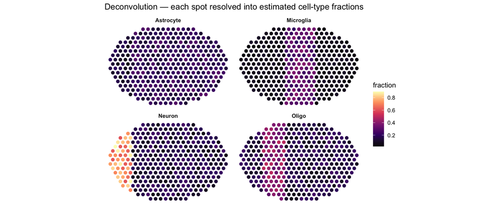

## Tools

| Tool | Method | Notes |
| --- | --- | --- |
| **RCTD / `spacexr`** | Maximum likelihood with cell-type-specific platform effects | Workshop default for Visium |
| **CARD** | Conditional autoregressive prior on neighborhood smoothness | Smoother results, harder to use |
| **cell2location** | Bayesian, Python | Atlas-scale; pairs natively with HCA |
| **SPOTlight** | Non-negative matrix factorization | Good when you don’t have a great reference |
| **CIBERSORTx** | Support-vector regression | Originally bulk; works on spatial |

**Tip**

**Use a tissue-matched reference.** Deconvolving a brain Visium with a PBMC reference returns garbage (PBMCs don’t include neurons). Match the reference to the tissue you sampled.

# Part 5 — Spatial-aware clustering

## Beyond standard SNN+Leiden

Standard clustering treats spots as iid points in expression space — but adjacent spots are spatially correlated. A spatial-aware clustering uses the tissue layout as an additional signal:

- **BANKSY** — augments each spot’s expression with its neighbors’ average expression before clustering
- **STAGATE** — graph attention auto-encoder on the spatial graph; learns smoother spatial domains
- **SpaGCN** — graph convolutional network combining expression + histology image
- **GraphST** — contrastive self-supervised graph learning

These typically yield **smoother, more biologically interpretable** spatial domains than standard Seurat clustering. Worth using for any “what are the regions?” question.

# Part 6 — Practical pitfalls

## Six things that bite

1. **A spot is not a cell.** Any “marker gene” plot you draw is a mixture readout. For cell-type questions, deconvolve.
2. **Edge effects.** The outermost spots only partially cover tissue and have lower UMI counts. Most pipelines treat them like the rest. Either filter (`SpatialFeaturePlot(... pt.size.factor = 1.0, alpha = c(0.0, 1))`) or annotate them.
3. **Cross-section integration.** Two sections from the same tissue still need integration — chip-to-chip variation is real. Same Harmony / SCT-anchor methods as scRNA-seq.
4. **Reference mismatch in deconvolution.** A reference that’s missing your tissue’s main cell type will distribute that cell’s transcripts across the cell types it does have. Always use a same-tissue reference.
5. **Over-interpreting the histology image.** The H&E underneath is a real image but is **registered**, not a ground truth — slight misalignment between spots and image is expected.
6. **Visium HD data volume.** A single Visium HD section is ~10 GB; loading naively into Seurat will OOM. Use the bin-aggregated outputs (8 µm, 16 µm) unless you really need 2 µm.

# Recap & what’s next

## What to remember from Lecture 12

- Spatial transcriptomics measures gene expression **while keeping the position** — answers “where” questions scRNA-seq throws away
- **Visium** is the workhorse (whole-tx, low resolution, easy); **Xenium / MERFISH / CosMx** trade coverage for resolution
- Visium spots are **mixtures** (1–10 cells) — clusters recover tissue regions, deconvolution recovers cell-type fractions
- **`SCTransform`** is the standard normalization; **Moran’s I** finds spatially variable genes
- Spatial-aware clustering (BANKSY, STAGATE) gives cleaner regions than vanilla SNN+Leiden
- Always plot QC metrics **on the tissue** — spatial QC is itself a sanity check

## Coming up next

- **Lec 11** — FAIR Principles & Data Sharing
- **Hands-on:** Tutorial 11 — Spatial Transcriptomics

## Further reading

- Moses & Pachter 2022, *Nat Methods* — comprehensive spatial-methods landscape, [doi:10.1038/s41592-022-01409-2](https://doi.org/10.1038/s41592-022-01409-2)
- Cable *et al.* 2022 — RCTD / spacexr, [doi:10.1038/s41587-021-00830-w](https://doi.org/10.1038/s41587-021-00830-w)
- Kleshchevnikov *et al.* 2022 — cell2location, [doi:10.1038/s41587-021-01139-4](https://doi.org/10.1038/s41587-021-01139-4)
- Singhal *et al.* 2024 — BANKSY, [doi:10.1038/s41588-024-01664-3](https://doi.org/10.1038/s41588-024-01664-3)
- [scNotebooks Module 10 — Spatial Transcriptomics](https://integrativebioinformatics.github.io/scNotebooks/modules/en/module10/module10.html)